# R/RStudio Training Session 4: Basic Statistics

Luting Xue

Auguest 25, 2020

# 1 Purpose and Intent

Perform Basic Statistical Analyses using R/Rstudio

- Distribution analysis
  - normality assessment
  - outlier testing
- Linear Regression
- Hypothesis testing
  - one- and two-sample t-tests
  - paired t-test
  - practical equivalence test (two one-sided t-test [TOST])
  - tests of variances
  - tests of proportions
- Statistical intervals
  - sample intervals
  - confidence intervals
  - tolerance intervals

**Note: R code is displayed in a grey box, and the results of that code displayed in a white box.**

# 2 Distribution Analysis

## 2.1 Normality assessment

### 2.1.1 Skewness and Kurtosis

```r
# create a vector with normally distributed values
test.data <- rnorm( 50,mean=0,sd=1 )

# data summary
summary(test.data)
```

```
##    Min. 1st Qu.  Median    Mean 3rd Qu.    Max.
## -2.0322 -0.5096 -0.1437 -0.1442  0.4783  1.3625
```

There is more than one method/package to estimate skewness and kurtosis. Use the package “e1071” to get the same results with JMP.

```r
library(e1071)
# calculate skewness, type 2 gets the same result with JMP
skewness(test.data,  na.rm=T,  type  =  2)
```

```
## [1] -0.4111488
```

```r
# calculate kurtosis, type 2 gets the same result with JMP
kurtosis(test.data,  na.rm=T,  type  =  2)
```

```
## [1] -0.3185427
```

Use a histogram to check the skewness and kurtosis visually.

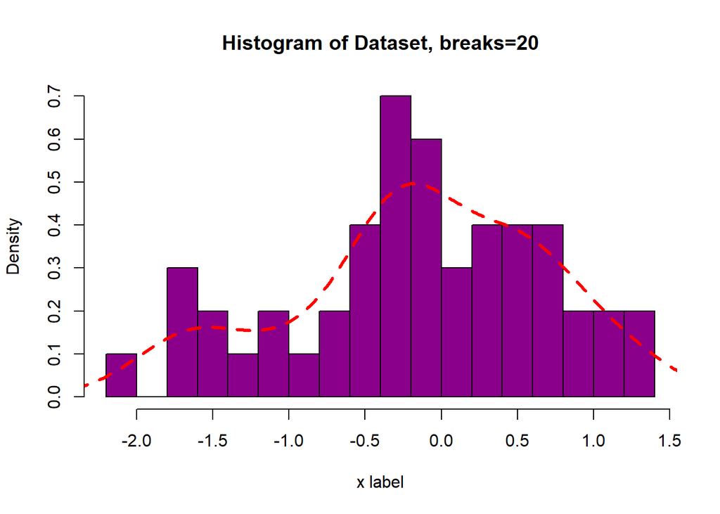

```r
hist(test.data,
main="Histogram of Dataset, breaks=20",   ## define title
xlab="x label",     ## define x label
col="darkmagenta",  ## define color
freq=F,             ## when freq=T, plot Frequency
breaks=20           ## define number of breaks
)

lines(density(test.data),  ## add a density line to the histogram
      lty  =  2,           ## line type is "dashed"
      col = "red",         ## color is red
      lwd=3)               ## specify line thickness
```

### 2.1.2 Shapiro-Wilk W Test

The Shapiro-Wilk W test returns a p-value associated with the probability that the data may be assumed to follow a Normal distribution. If p ≥ 0.05, the data may be reasonably approximated using a Normal distribution. If p < 0.05, the data may not be reasonably approximated using a Normal distribution.

```r
shapiro.test(test.data)
```

```
##
##  Shapiro-Wilk normality test
##
## data:  test.data
## W = 0.96903, p-value = 0.2112
```

### 2.1.3 Quantile-Quantile Plots

Use a QQplot to check the normality visually.

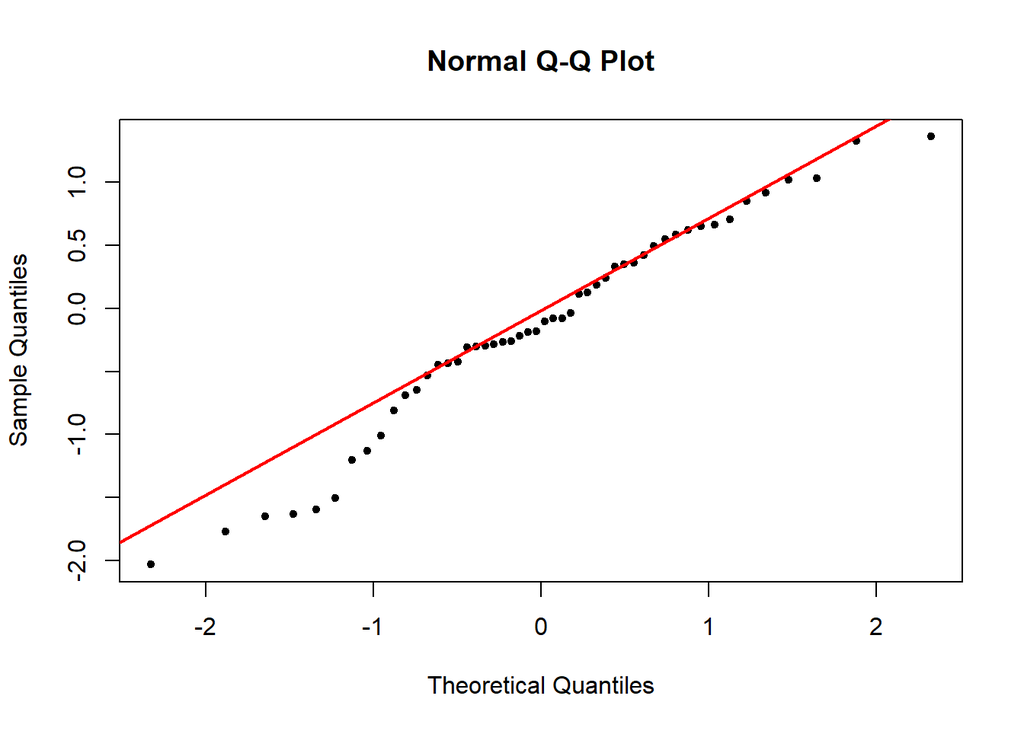

```r
## produces a normal QQ plot for given numerical vector, pch: specify the point type
qqnorm(test.data,pch=20)
## add a theoretical line, specifing color and thickness of the line
qqline(test.data,col="red",lwd=2)
```